# Walmart - Store Sales Forecasting

## Sales prediction for single store

#### Prepare Model

```python
#Constants
cols = ['temperature', 'fuel_price', 'cpi', 'unemployment']

#cols_a = ['cpi', 'unemployment']

#cols_b = ['temperature', 'fuel_price']

#cols_c = ['fuel_price']

#cols_d = ['temperature']
```

```python
#Prepare X and y - build a model for Weekly Sales
X = dfx[cols]
y = dfx['weekly_sales']
```

### Feature Selection

#### F Values

```python
from sklearn import feature_selection as fs

def f_regression_feature_selection(input, response):
# use this against your feature matrix to determine p-values for
# each feature (we care about the second array it returns).
    return fs.univariate_selection.f_regression(input, response)
```

```python
# How many features don't meet the F test threshold?
sum(f_regression_feature_selection(X,y)[0] < 6)
```

```
0
```

```python
# Which column are we talking about?
select = f_regression_feature_selection(X,y)[0] < 6
X.columns[select]
```

```
Index([], dtype='object')
```

```python
# difference between the ones available and the ones we wish to drop
select = pd.Index(X.columns).difference(pd.Index(X.columns[select]))

Xs = X[select]
```

```python
Xs.head()
```

|  | cpi | fuel_price | temperature | unemployment |
| --- | --- | --- | --- | --- |
| 286548 | 210.752605 | 2.572 | 39.05 | 8.324 |
| 286549 | 210.897994 | 2.548 | 37.77 | 8.324 |
| 286550 | 210.945160 | 2.514 | 39.75 | 8.324 |
| 286551 | 210.975957 | 2.561 | 45.31 | 8.324 |
| 286552 | 211.006754 | 2.625 | 48.61 | 8.324 |

According to the F Value test, we should build a model using only the variable of temperature (because only temperature passess the threshold test)! However, for purposes of the exercise, we will proceed with evaluating p values. Note: for purposes of analysis, we have arbitrarily reduced the F test threshold above from 10 to 6 so that we can proceed to study all features.

#### P Values

```python
# How many features don't meet the F test threshold?
sum(f_regression_feature_selection(Xs,y)[1] > 0.05)
```

```
0
```

This suggests all of the features are significant ( p < 0.05 ) in a univariate regression.

```python
# Sort the features based on their statistical significance
ps = f_regression_feature_selection(Xs,y)[1]

p_score = zip(Xs.columns, ps)
ranked_p = sorted(p_score, key=lambda x:x[1])
ranked_p
```

```
[('temperature', 0.00015070018819721294),
 ('fuel_price', 0.0077889931366162514),
 ('cpi', 0.0081977209830771045),
 ('unemployment', 0.012865708030999807)]
```

```python
from sklearn.linear_model import Ridge
```

```python
# Build univariate models to see how well each individual feature performs
scores = []
for feat, score in ranked_p:
    est = Ridge()
    X = [[x] for x in Xs[feat]]
    est.fit(X,y)
    scores.append(est.score(X,y))
```

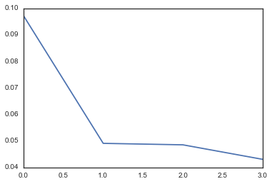

```python
# Drop of R^2 with strong to weakest features
plt.plot(range(len(scores)), scores)
```

All the values below 0.1. None of the features appear to have strong power predicting weekly sales, but relatively speaking, the first feature - temperature stands out.

```python
# Build models which cummatively look at how well combinations of features perform
scores = []
feats = []
for feat, score in ranked_p:
    est = Ridge()
    feats.append(feat)
    if len(feats) == 1:
        X = [[x] for x in Xs[feat]]
    else:
        X = Xs[feats]
    est.fit(X, y)
    scores.append(est.score(X,y))
```

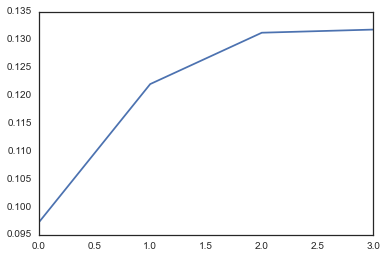

```python
# Drop of R^2 with strong to weakest features
plt.plot(range(len(scores)), scores)
```

The temperature is the most relevant feature.

```python
correlation = Xs[[x[0] for x in ranked_p][:]]
```

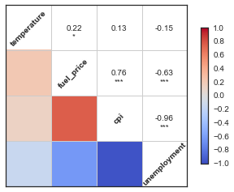

```python
sns.corrplot(correlation)
```

The fuel_price has strong correlation with CPI

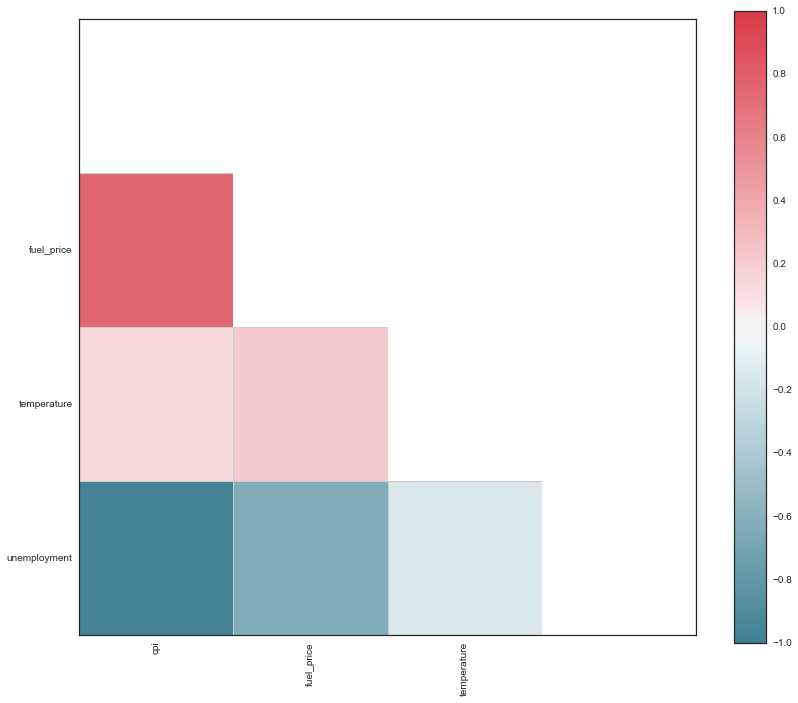

```python
f, ax = plt.subplots(figsize=(12, 12))
cmap = sns.diverging_palette(220, 10, as_cmap=True)
sns.corrplot(Xs, annot=False, sig_stars=False,
             diag_names=False, cmap=cmap, ax=ax)
f.tight_layout()
```

Based on the P Values, the most important features are (ranked): temperate, fuel_price, then cpi and umployment.

```python
p_features = [x[0] for x in ranked_p][:]
p_features
```

```
['temperature', 'fuel_price', 'cpi', 'unemployment']
```

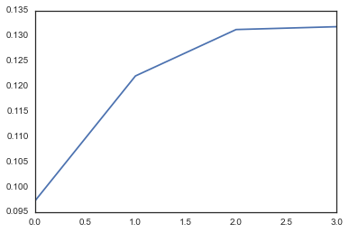

```python
# Drop of R^2 with strong to weakest features
plt.plot(range(len(scores)), scores)
```

As seen above, fuel price has more impact in the improvement in R^2 than cpi or unemployment. Below is feature selection - by manual selection.

#### Feature Selection - Manual

```python
fs_manual = [ranked_p[x][0] for x in [1,2]]
print fs_manual
```

```
['fuel_price', 'cpi']
```

```python
est = Ridge()
X_manual = Xs[fs_manual]
est.fit(X_manual, y).score(X_manual,y)
```

```
0.05560338883001037
```

#### Feature Selection - Forward Selection

```python
scores = []
feats = []
features = feats[:]
for i in range(len(X.columns)):
    scores = []
    for feat in X.columns.difference(features):
        est = Ridge()
        feats = features[:]
        feats.append(feat)
        Xs = X[feats]
        #print feats
        est.fit(Xs, y)
        feats = features
        scores.append([feat,est.score(Xs,y)])
    dfx = pd.DataFrame(scores, columns=['a','s'])
    dfx.index = dfx.a
    #print dfx
    addfeat = dfx.s.argmax()
    print ('Added feature: ' + addfeat + ', new score is: ' + str(dfx.s.max()))
    features.append(addfeat)
```

```
Added feature: temperature, new score is: 0.0971755354011
Added feature: cpi, new score is: 0.130195532649
Added feature: unemployment, new score is: 0.131614610821
Added feature: fuel_price, new score is: 0.131779290346
```

```python
fs_fwd = features[:]
```

```python
print fs_fwd
```

```
['temperature', 'cpi', 'unemployment', 'fuel_price']
```

#### Feature Selection - RFE

```python
stand_X = (X - X.mean()) / X.std()
```

```python
stand_X.columns
```

```
Index([u'temperature', u'fuel_price', u'cpi', u'unemployment'], dtype='object')
```

```python
from sklearn.feature_selection import RFE

# Create the RFE object and rank each feature
est = Ridge(alpha = 100)
rfe = RFE(estimator=est, n_features_to_select=1, step=1)

rfe.fit(stand_X, y)
ranking = rfe.ranking_

scores = zip(Xs.columns,ranking)
scores = sorted(scores, key=lambda x:x[1])
fs_rfe = [x[0] for x in scores][:]
```

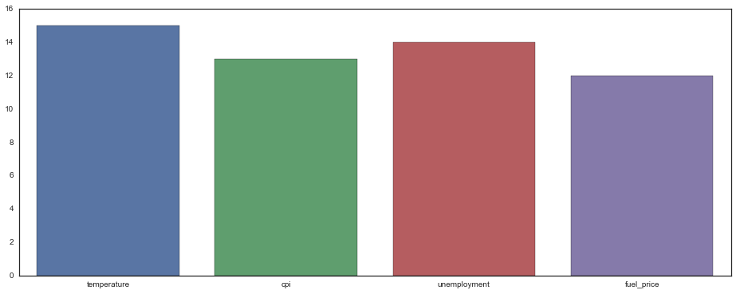

```python
plt.figure(figsize=(16, 6))
sns.barplot(Xs.columns, 16 - ranking);
```

From the above chart, the priority of the important features are temperature, unemployment, CPI then fuel_price.

```python
print 'Feature Selection - Manual:', fs_manual
print 'Feature Selection - Forward Selection (p-value):', fs_fwd
print 'Feature Selection - RFE:', fs_rfe
```

[output not shown]

```python
for feats in [fs_manual, fs_fwd, fs_rfe]:
    est = Ridge()
    Xs = X[feats]
    print est.fit(Xs, y).score(Xs,y)
```

```
0.05560338883
0.131779290346
0.131779290346
```

Feature selection via forward selection or RFE is better than handpicking, but overall, neither appears to be a strong model!!

```python
Xs = stand_X[fs_rfe]
Xs = sm.add_constant(Xs)
```

```python
regress = sm.OLS(y,Xs)
results = regress.fit()
```

```python
print results.summary()
```

```
                            OLS Regression Results
==============================================================================
Dep. Variable:           weekly_sales   R-squared:                       0.132
Model:                            OLS   Adj. R-squared:                  0.107
Method:                 Least Squares   F-statistic:                     5.238
Date:                Sun, 12 Jun 2016   Prob (F-statistic):           0.000586
Time:                        22:29:52   Log-Likelihood:                -1303.7
No. Observations:                 143   AIC:                             2617.
Df Residuals:                     138   BIC:                             2632.
Df Model:                           4
Covariance Type:            nonrobust
================================================================================
                   coef    std err          t      P>|t|      [95.0% Conf. Int.]
--------------------------------------------------------------------------------
const         9788.3766    187.602     52.176      0.000      9417.431  1.02e+04
temperature   -683.0537    198.114     -3.448      0.001     -1074.784  -291.323
unemployment  -261.5839    849.730     -0.308      0.759     -1941.759  1418.591
cpi           -646.0069   1011.474     -0.639      0.524     -2645.998  1353.984
fuel_price     -53.8229    359.419     -0.150      0.881      -764.502   656.857
==============================================================================
Omnibus:                      104.880   Durbin-Watson:                   1.262
Prob(Omnibus):                  0.000   Jarque-Bera (JB):              789.439
Skew:                           2.641   Prob(JB):                    3.76e-172
Kurtosis:                      13.227   Cond. No.                         11.5
==============================================================================

Warnings:
[1] Standard Errors assume that the covariance matrix of the errors is correctly specified.
```